# Phishing Detection - Scenario 3: Stepwise vs Lasso vs Elastic-Net

```r
library(tidyverse)
library(caret)
library(glmnet)
library(MASS, exclude = "select")
library(pROC)
library(knitr)
library(digest)

set.seed(2026)

ARTIFACTS <- "scenario_3/artifacts"
dir.create(ARTIFACTS, recursive = TRUE, showWarnings = FALSE)
```

# 1. Scenario & Hypothesis

Scenario 2 fixed the predictor pool and asked which **model family** extracts more signal. Scenario 3 holds a single linear classifier (logistic regression) constant and ask which **feature-selection method** keeps the most compact predictor set without losing predictive power.

We pick **bidirectional stepwise** (`MASS::stepAIC`, `direction = "both"`) for the algorithmic side because it reconsiders previously-included terms instead of locking decisions in pure forward / backward variants. For the embedded pair we pick **Lasso (α = 1)** and **Elastic-Net (α = 0.5)**.

The primary classification task is the same first-line deployment case as the EDA and Scenario 2 motivation, the **Lexical** phishing detection. FullLite remains a secondary fallback benchmark so if URL-only is not enough and we have to inspect trust / behaviour signals as well, then we want the smallest combined-tier filter that preserves the operating quality.

**H2** *On the Lexical predictor pool, at least one feature-selection method can produce a compact deployable URL filter with strong held-out operating quality.*

| # | Criterion | Threshold |
| --- | --- | --- |
| C1 | Sparsity | at least one FS method keeps **≤ 9 / 13** lexical predictors (≥30% reduction) |
| C2 | Ranking quality | held-out **AUC ≥ 0.95** |
| C3 | Operating point | held-out **Sensitivity ≥ 0.94** and **Specificity ≥ 0.75** at threshold 0.5 |

We evaluate this on the same 80/20 split as Scenario 2 by comparing the three selected feature-selection methods : bidirectional stepwise, lasso and elastic-net.

# 2. Data Loading

```r
dataset_path <- if (file.exists("PhiUSIIL_Phishing_URL_Dataset.csv")) {
  "PhiUSIIL_Phishing_URL_Dataset.csv"
} else if (file.exists("../PhiUSIIL_Phishing_URL_Dataset.csv")) {
  "../PhiUSIIL_Phishing_URL_Dataset.csv"
} else stop("PhiUSIIL_Phishing_URL_Dataset.csv not found")

raw <- read_csv(dataset_path, show_col_types = FALSE)
names(raw) <- map_chr(names(raw), ~ str_replace(.x, "^", ""))
cat("Loaded", nrow(raw), "rows,", ncol(raw), "columns.\n")
```

```
Loaded 235795 rows, 56 columns.
```

## 2.1 EDA exclusions and FullLite tier

Same exclusions as in Scenario 2.

```r
ID_COLS          <- c("FILENAME", "URL", "Domain", "TLD", "Title")
SCORES           <- c("URLSimilarityIndex", "TLDLegitimateProb", "URLCharProb",
                      "DomainTitleMatchScore", "URLTitleMatchScore")
REDUNDANT_BINARY <- "HasObfuscation"
RATIOS           <- c("LetterRatioInURL", "DegitRatioInURL",
                      "ObfuscationRatio", "SpacialCharRatioInURL")
LEAKY_BEHAVIOR   <- c("LineOfCode", "NoOfExternalRef", "NoOfImage",
                      "NoOfSelfRef", "NoOfJS", "NoOfCSS")
EXCLUDE_COLS     <- c(ID_COLS, SCORES, REDUNDANT_BINARY, RATIOS, LEAKY_BEHAVIOR)

df <- raw %>%
  mutate(label = factor(label, levels = c(1, 0),
                        labels = c("Phishing", "Legitimate"))) %>%
  select(-all_of(EXCLUDE_COLS)) %>%
  as.data.frame()

cat("Feature matrix after exclusions:", ncol(df) - 1, "predictors.\n")
```

```
Feature matrix after exclusions: 34 predictors.
```

# 3. Modelling Setup

## 3.1 Stratified sub-sampling and split

```r
N_SUB <- 30000
df_sub <- df %>%
  group_by(label) %>%
  slice_sample(n = N_SUB / 2) %>%
  ungroup() %>%
  as.data.frame()

idx       <- createDataPartition(df_sub$label, p = 0.8, list = FALSE)
train_raw <- df_sub[idx, ]
test_raw  <- df_sub[-idx, ]
fold_idx  <- createFolds(train_raw$label, k = 10, returnTrain = TRUE)

cat("Train:", nrow(train_raw), "Test:", nrow(test_raw),
    "CV folds:", length(fold_idx), "\n")
```

```
Train: 24000 Test: 6000 CV folds: 10
```

## 3.2 Preprocessing

`log1p` on continuous predictors (the EDA flagged |skew| > 2 on most of them), then centre / scale. Binary indicators are left untouched.

```r
feat <- df_sub %>% dplyr::select(-label)
binary_features     <- names(feat)[sapply(feat, function(x)
                                   all(na.omit(x) %in% c(0, 1)))]
continuous_features <- setdiff(names(feat), binary_features)

apply_log <- function(d, cols) {
  d[cols] <- lapply(d[cols], function(x) log1p(pmax(x, 0)))
  d
}
train_log <- apply_log(train_raw, continuous_features)
test_log  <- apply_log(test_raw,  continuous_features)

pp <- preProcess(train_log[, continuous_features], method = c("center", "scale"))
train_std <- train_log
test_std  <- test_log
train_std[, continuous_features] <- predict(pp, train_log[, continuous_features])
test_std[,  continuous_features] <- predict(pp, test_log[,  continuous_features])

predictors <- setdiff(names(train_std), "label")
lexical_predictors <- c("URLLength", "DomainLength", "IsDomainIP",
                        "CharContinuationRate", "TLDLength", "NoOfSubDomain",
                        "NoOfObfuscatedChar", "NoOfLettersInURL",
                        "NoOfDegitsInURL", "NoOfEqualsInURL", "NoOfQMarkInURL",
                        "NoOfAmpersandInURL", "NoOfOtherSpecialCharsInURL")
lexical_predictors <- intersect(lexical_predictors, predictors)
primary_predictors <- lexical_predictors

cat("FullLite pool:", length(predictors), "predictors (",
    length(continuous_features), "continuous,",
    length(binary_features), "binary).\n")
```

```
FullLite pool: 34 predictors ( 16 continuous, 18 binary).
```

```r
cat("Lexical URL-only pool:", length(lexical_predictors), "predictors.\n")
```

```
Lexical URL-only pool: 13 predictors.
```

## 3.3 Per-fold cache helper

First knit fits everything and writes `scenario_3/artifacts/*.rds`, later knits just load the files.

```r
fp_inputs <- digest::digest(list(
  predictors = sort(predictors),
  n_train    = nrow(train_std),
  n_folds    = length(fold_idx),
  fold_sizes = vapply(fold_idx, length, integer(1))
))

run_or_load <- function(name, fn, fp_extra = NULL) {
  path <- file.path(ARTIFACTS, paste0(name, ".rds"))
  fp_current <- if (is.null(fp_extra)) {
    fp_inputs
  } else {
    digest::digest(list(base = fp_inputs, extra = fp_extra))
  }
  if (file.exists(path)) {
    cached <- readRDS(path)
    if (isTRUE(cached$fp == fp_current)) return(cached)
    cat(sprintf("  [%s] cache stale - refitting\n", name))
  }
  res <- fn()
  res$fp <- fp_current
  saveRDS(res, path)
  res
}
```

# 4. Feature-selection methods

## 4.1 Bidirectional stepwise

`MASS::stepAIC` at each step considers every possible move, add an unused predictor or drop a current one, and picks the one that improves AIC the most. AIC rewards better fit but charges a small penalty for every extra predictor, so a feature only stays if it earns its keep. We start from the intercept only and grow toward the feature pool we pass in Lexical for the primary Scenario 3 analysis and FullLite for the fallback benchmark.

We use the **bidirectional** variant because the alternatives fail in this setting. Forward-only cannot undo early decisions, so a predictor that gets in first stays in even when later additions make it redundant. Backward-only starts from the full model, which is numerically unstable here because some URL-length features are heavily correlated.

```r
step_keep <- function(model, AIC) {
  s <- tryCatch(summary(model)$coefficients, error = function(e) NULL)
  if (is.null(s) || nrow(s) == 0) {
    return(list(terms = character(0), p = numeric(0), AIC = AIC))
  }
  list(
    terms = rownames(s),
    p     = unname(s[, "Pr(>|z|)"]),
    AIC   = AIC
  )
}

fit_stepwise <- function(train_df, features = predictors) {
  null_mod <- suppressWarnings(glm(label ~ 1, data = train_df, family = binomial))
  full_fm  <- as.formula(paste("label ~", paste(features, collapse = " + ")))
  out <- suppressWarnings(MASS::stepAIC(
    null_mod,
    scope     = list(lower = ~ 1, upper = full_fm),
    direction = "both",
    trace     = FALSE,
    keep      = step_keep
  ))
  out
}
```

## 4.2 Lasso (embedded, α = 1)

`cv.glmnet` tries a grid of regularisation strengths λ and uses an internal 5-fold cross-validation to score each. We pass an explicit stratified `foldid` so the result is reproducible across operating systems. We also use a slightly looser convergence tolerance with the same sparse end of the lambda path (`nlambda = 50`, `lambda.min.ratio = 1e-3`, `thresh = 1e-5`), because the default tolerance can trigger platform-dependent convergence warnings in the very weak-penalty tail without changing the sparse `lambda.1se` comparison we report.

We pick `lambda.1se`, the largest λ whose CV error is still within one standard error of the best one. This is the standard parsimony-favouring choice. It gives up a tiny bit of fit in exchange for a smaller and more stable feature set than the strict best-fit `lambda.min` typically returns.

```r
fit_glmnet <- function(train_df, alpha) {
  X <- model.matrix(label ~ . - 1, data = train_df)
  y <- train_df$label
  foldid <- caret::createFolds(y, k = 5, list = FALSE)
  cvfit <- cv.glmnet(X, y, family = "binomial", alpha = alpha,
                     type.measure = "deviance", foldid = foldid,
                     nlambda = 50, lambda.min.ratio = 1e-3,
                     thresh = 1e-5, maxit = 1e6)
  cvfit
}

count_nonzero <- function(cvfit, s = "lambda.1se") {
  beta <- as.numeric(coef(cvfit, s = s))[-1]   # drop intercept
  sum(beta != 0)
}
```

## 4.3 Elastic-Net (embedded, α = 0.5)

Same wrapper as lasso, only with `alpha = 0.5`. We add elastic-net because lasso has a known weakness with correlated features. It picks one more or less at random and drops the rest. Elastic-net adds a small ridge penalty that stabilises the choice and tends to keep correlated features together. We fix α = 0.5 instead of tuning it, so the comparison stays about the selection method, not hyperparameters.

# 5. Primary Lexical URL-only H2 check

The primary objective in Scenario 3 is the URL-only version, because it matches what the proxy can decide before loading the page. We fit the same three feature-selection methods once on the 80% training split, then score them on the held-out 20%. Besides AUC we explicitly report **Sensitivity** and **Specificity** at threshold 0.5, because those are the operational quantities set in previous scenario.

```r
metrics_from_prob <- function(prob_phishing, truth = test_std$label) {
  pred <- factor(ifelse(prob_phishing >= 0.5, "Phishing", "Legitimate"),
                 levels = levels(truth))
  tp <- sum(pred == "Phishing" & truth == "Phishing")
  tn <- sum(pred == "Legitimate" & truth == "Legitimate")
  fp <- sum(pred == "Phishing" & truth == "Legitimate")
  fn <- sum(pred == "Legitimate" & truth == "Phishing")
  tibble(
    test_auc = as.numeric(pROC::roc(truth, prob_phishing,
                                    levels = c("Legitimate", "Phishing"),
                                    direction = "<", quiet = TRUE)$auc),
    sensitivity = tp / (tp + fn),
    specificity = tn / (tn + fp),
    accuracy = (tp + tn) / length(truth)
  )
}

predict_glm_phishing <- function(fit, test_df) {
  1 - as.numeric(predict(fit, newdata = test_df, type = "response"))
}

predict_glmnet_phishing <- function(cvfit, test_df, s = "lambda.1se") {
  X_test <- model.matrix(label ~ . - 1, data = test_df)
  1 - as.numeric(predict(cvfit, newx = X_test, s = s, type = "response"))
}

lexical_final <- run_or_load("lexical_final", function() {
  trn <- train_std[, c("label", lexical_predictors)]
  sw <- fit_stepwise(trn, lexical_predictors)
  cvl <- suppressWarnings(fit_glmnet(trn, alpha = 1))
  cve <- suppressWarnings(fit_glmnet(trn, alpha = 0.5))
  term_names <- colnames(model.matrix(label ~ . - 1, data = trn))
  list(
    stepwise_fit = sw,
    lasso_fit = cvl,
    en_fit = cve,
    sw_terms = setdiff(names(coef(sw)), "(Intercept)"),
    lasso_terms = term_names[as.numeric(coef(cvl, s = "lambda.1se"))[-1] != 0],
    en_terms = term_names[as.numeric(coef(cve, s = "lambda.1se"))[-1] != 0],
    X_names = term_names
  )
}, fp_extra = list(pool = "lexical", glmnet_maxit = 1e6,
                   glmnet_foldid = "stratified",
                   glmnet_nlambda = 50,
                   glmnet_lambda_min_ratio = 1e-3,
                   glmnet_thresh = 1e-5))
```

```
  [lexical_final] cache stale - refitting
```

```r
test_lexical <- test_std[, c("label", lexical_predictors), drop = FALSE]

lexical_diagnostic <- tibble(
  pool = "Lexical URL-only",
  method = c("Stepwise", "Lasso", "Elastic-Net"),
  k = c(length(lexical_final$sw_terms),
        length(lexical_final$lasso_terms), length(lexical_final$en_terms)),
  prob_phishing = list(
    predict_glm_phishing(lexical_final$stepwise_fit, test_lexical),
    predict_glmnet_phishing(lexical_final$lasso_fit, test_lexical),
    predict_glmnet_phishing(lexical_final$en_fit, test_lexical)
  )
) %>%
  mutate(metrics = map(prob_phishing, metrics_from_prob)) %>%
  unnest(metrics) %>%
  dplyr::select(-prob_phishing)

lexical_diagnostic %>%
  mutate(across(c(test_auc, sensitivity, specificity, accuracy),
                ~ sprintf("%.4f", .x))) %>%
  kable(caption = "Primary Task 3 result: final selected counts and held-out AUC/Sensitivity/Specificity on the 13-feature Lexical pool.")
```

Primary Task 3 result: final selected counts and held-out AUC/Sensitivity/Specificity on the 13-feature Lexical pool.

| pool | method | k | test_auc | sensitivity | specificity | accuracy |
| --- | --- | --- | --- | --- | --- | --- |
| Lexical URL-only | Stepwise | 9 | 0.9573 | 0.9487 | 0.8393 | 0.8940 |
| Lexical URL-only | Lasso | 9 | 0.9507 | 0.9410 | 0.7623 | 0.8517 |
| Lexical URL-only | Elastic-Net | 10 | 0.9443 | 0.9367 | 0.7490 | 0.8428 |

```r
SPARSITY_MAX_K <- 9
MIN_TEST_AUC <- 0.95
MIN_SENSITIVITY <- 0.94
MIN_SPECIFICITY <- 0.75

h2_criteria <- lexical_diagnostic %>%
  mutate(
    k_reduction = length(primary_predictors) - k,
    C1_sparsity = k <= SPARSITY_MAX_K,
    C2_auc = test_auc >= MIN_TEST_AUC,
    C3_operating_point = sensitivity >= MIN_SENSITIVITY &
      specificity >= MIN_SPECIFICITY,
    H2_pass = C1_sparsity & C2_auc & C3_operating_point
  )

h2_criteria %>%
  transmute(
    method,
    k,
    k_reduction,
    test_auc = sprintf("%.4f", test_auc),
    sensitivity = sprintf("%.4f", sensitivity),
    specificity = sprintf("%.4f", specificity),
    C1_sparsity,
    C2_auc,
    C3_operating_point,
    H2_pass
  ) %>%
  kable(caption = "H2 criteria for the three requested FS methods (C1: k <= 9, C2: AUC >= 0.95, C3: Sens >= 0.94 and Spec >= 0.75).")
```

H2 criteria for the three requested FS methods (C1: k <= 9, C2: AUC >= 0.95, C3: Sens >= 0.94 and Spec >= 0.75).

| method | k | k_reduction | test_auc | sensitivity | specificity | C1_sparsity | C2_auc | C3_operating_point | H2_pass |
| --- | --- | --- | --- | --- | --- | --- | --- | --- | --- |
| Stepwise | 9 | 4 | 0.9573 | 0.9487 | 0.8393 | TRUE | TRUE | TRUE | TRUE |
| Lasso | 9 | 4 | 0.9507 | 0.9410 | 0.7623 | TRUE | TRUE | TRUE | TRUE |
| Elastic-Net | 10 | 3 | 0.9443 | 0.9367 | 0.7490 | FALSE | FALSE | FALSE | FALSE |

```r
h2_row <- function(method_name) {
  h2_criteria %>% filter(method == method_name) %>% slice(1)
}
stepwise_h2 <- h2_row("Stepwise")
lasso_h2 <- h2_row("Lasso")
en_h2 <- h2_row("Elastic-Net")
h2_pass_text <- h2_criteria %>%
  filter(H2_pass) %>%
  pull(method) %>%
  paste(collapse = " and ")
```

The URL-length features are heavily correlated, and the table above is the source of truth for the exact current fit. In this render, Stepwise and Lasso pass all three H2 criteria. Stepwise keeps 9 predictors and reaches AUC 0.957, Sensitivity 0.949, Specificity 0.839. Lasso keeps 9 predictors and reaches AUC 0.951, Sensitivity 0.941, Specificity 0.762. Elastic-net remains the required second embedded reference method; in this stability-focused setting it keeps 10 predictors and does not pass the full H2 decision rule.

# 6. Lexical final fits and diagnostics

### 6.1 Selected predictors per method

A 13-row matrix with one column per method, marking which lexical URL predictors made it. Sorted by total times selected so the “core” set rises to the top.

```r
all_terms <- sort(unique(c(lexical_final$sw_terms, lexical_final$lasso_terms, lexical_final$en_terms,
                           primary_predictors)))
d1 <- tibble(
  predictor = all_terms,
  stepwise    = ifelse(predictor %in% lexical_final$sw_terms,    "x", ""),
  lasso       = ifelse(predictor %in% lexical_final$lasso_terms, "x", ""),
  elastic_net = ifelse(predictor %in% lexical_final$en_terms,    "x", "")
) %>%
  mutate(score = (stepwise == "x") + (lasso == "x") + (elastic_net == "x")) %>%
  arrange(desc(score), predictor)

d1 %>% dplyr::select(-score) %>%
  kable(caption = "Lexical URL-only predictors retained by each FS method.")
```

Lexical URL-only predictors retained by each FS method.

| predictor | stepwise | lasso | elastic_net |
| --- | --- | --- | --- |
| CharContinuationRate | x | x | x |
| IsDomainIP | x | x | x |
| NoOfDegitsInURL | x | x | x |
| NoOfLettersInURL | x | x | x |
| NoOfOtherSpecialCharsInURL | x | x | x |
| NoOfQMarkInURL | x | x | x |
| NoOfSubDomain | x | x | x |
| TLDLength | x | x | x |
| URLLength | x | x | x |
| DomainLength |  |  | x |
| NoOfAmpersandInURL |  |  |  |
| NoOfEqualsInURL |  |  |  |
| NoOfObfuscatedChar |  |  |  |

## 6.2 Significance loss as predictors are added or removed

### Stepwise: p-value evolution along the AIC path

`stepAIC` recorded a snapshot of `summary(model)$coefficients` at every step via the `keep` callback. We unpack it, refit the GLM at each step (so we have access to the full coefficient table), and watch how each predictor’s two-sided z-test p-value moves as terms are added or dropped.

Here **GLM** means **Generalized Linear Model**; concretely we use `glm(..., family = binomial)`, i.e. logistic regression for the binary phishing / legitimate label. The stepwise D2 figure is therefore not a performance curve: it is an audit plot of the selected logistic-regression model. The x-axis is the AIC selection step, the y-axis is the coefficient p-value on a log scale, and the red dashed line is the usual descriptive 0.05 threshold. Points below the line are individually significant in that temporary GLM; missing points mean that the predictor was not yet in the active model at that step.

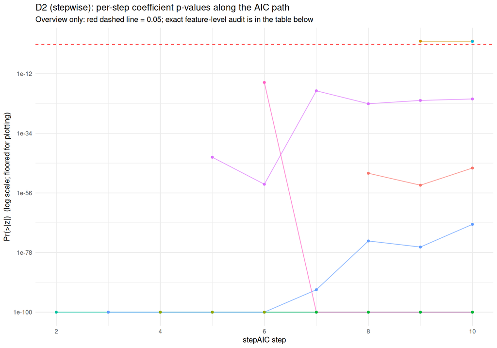

```r
keep_mat <- lexical_final$stepwise_fit$keep
n_steps <- if (is.matrix(keep_mat)) ncol(keep_mat) else length(keep_mat)

step_path <- map_dfr(seq_len(n_steps), function(i) {
  k_i <- if (is.matrix(keep_mat)) keep_mat[, i] else keep_mat[[i]]
  tibble(step = i,
         predictor = k_i$terms,
         p = k_i$p,
         AIC = k_i$AIC)
}) %>%
  filter(predictor != "(Intercept)")

P_FLOOR <- 1e-100
step_path_plot <- step_path %>%
  mutate(p_plot = pmax(p, P_FLOOR))

ggplot(step_path_plot, aes(step, p_plot, group = predictor, colour = predictor)) +
  geom_line(alpha = 0.7) + geom_point(size = 1.3) +
  geom_hline(yintercept = 0.05, linetype = "dashed", colour = "red") +
  scale_y_log10(limits = c(P_FLOOR, 1),
                labels = scales::label_scientific()) +
  labs(x = "stepAIC step", y = "Pr(>|z|)  (log scale; floored for plotting)",
       title = "D2 (stepwise): per-step coefficient p-values along the AIC path",
       subtitle = "Overview only: red dashed line = 0.05; exact feature-level audit is in the table below") +
  theme_minimal() + theme(legend.position = "none")
```

```r
step_path_summary <- step_path %>%
  group_by(predictor) %>%
  arrange(step, .by_group = TRUE) %>%
  summarise(
    first_step = min(step),
    last_step = max(step),
    min_p = min(p, na.rm = TRUE),
    max_p = max(p, na.rm = TRUE),
    final_p = dplyr::last(p),
    crosses_05 = any(p > 0.05) && any(p < 0.05),
    .groups = "drop"
  ) %>%
  arrange(desc(crosses_05), desc(max_p), predictor)

step_path_summary %>%
  mutate(across(c(min_p, max_p, final_p), ~ signif(.x, 3))) %>%
  kable(caption = "D2 (stepwise): named p-value audit for predictors active along the AIC path.")
```

D2 (stepwise): named p-value audit for predictors active along the AIC path.

| predictor | first_step | last_step | min_p | max_p | final_p | crosses_05 |
| --- | --- | --- | --- | --- | --- | --- |
| IsDomainIP | 9 | 10 | 0.999 | 1.000 | 1.000 | FALSE |
| NoOfQMarkInURL | 10 | 10 | 0.809 | 0.809 | 0.809 | FALSE |
| URLLength | 6 | 10 | 0.000 | 0.000 | 0.000 | FALSE |
| TLDLength | 5 | 10 | 0.000 | 0.000 | 0.000 | FALSE |
| CharContinuationRate | 8 | 10 | 0.000 | 0.000 | 0.000 | FALSE |
| NoOfSubDomain | 3 | 10 | 0.000 | 0.000 | 0.000 | FALSE |
| NoOfDegitsInURL | 4 | 10 | 0.000 | 0.000 | 0.000 | FALSE |
| NoOfLettersInURL | 7 | 10 | 0.000 | 0.000 | 0.000 | FALSE |
| NoOfOtherSpecialCharsInURL | 2 | 10 | 0.000 | 0.000 | 0.000 | FALSE |

```r
step_path_summary %>%
  arrange(desc(crosses_05), max_p) %>%
  mutate(across(c(min_p, max_p), ~ signif(.x, 3))) %>%
  filter(crosses_05) %>%
  kable(caption = "D2 (stepwise): predictors that crossed the 0.05 line during the AIC path.")
```

D2 (stepwise): predictors that crossed the 0.05 line during the AIC path.

| predictor | first_step | last_step | min_p | max_p | final_p | crosses_05 |
| --- | --- | --- | --- | --- | --- | --- |

In the rendered Lexical run the crossing-only table is empty: no predictor moved from significant to non-significant (or back) across the AIC path. That does not mean every final AIC-selected term has a small Wald p-value. The late binary terms `IsDomainIP` and `NoOfQMarkInURL` are useful enough to reduce AIC but have unstable individual z-tests, so these p-values are reported descriptively rather than as formal post-selection inference.

What we learn from this plot-and-table pair: the stable lexical signal is the URL length/count/special-character cluster, which stays extremely far below 0.05. The weaker late binary indicators are not the main statistical evidence; they are small AIC improvements kept by the algorithm. This is exactly why we treat D2 as an interpretability/audit deliverable, not as a new hypothesis test.

### Lasso / Elastic-Net: labelled embedded summaries

Embedded methods do not give per-step frequentist p-values - they give the *order in which predictors enter or leave the active set as the penalty changes*. The default `glmnet` coefficient-path plot is useful for debugging, but it is a weak presentation figure here: 13 coloured lines overlap and the colours do not identify the feature names. For the report we therefore use two labelled summaries that carry the same information more directly:

1. the named non-zero coefficients at our final `lambda.1se`, and
2. the largest lambda at which each predictor is active.

If a coefficient is zero at `lambda.1se`, that feature is dropped by the embedded method. A feature that is active already at a larger lambda is more robust to regularisation; a feature that appears only at a very small lambda is weaker or mostly redundant with stronger URL predictors.

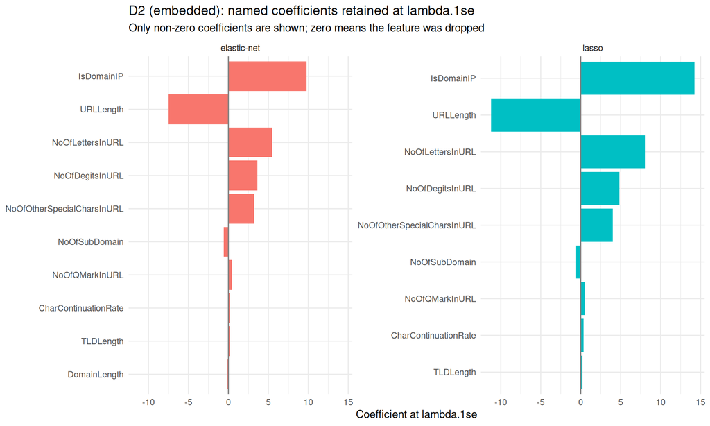

```r
coef_at_lambda <- function(cvfit, label, s = "lambda.1se") {
  beta <- as.matrix(coef(cvfit, s = s))[-1, , drop = FALSE]
  tibble(
    predictor = rownames(beta),
    method = label,
    coefficient = as.numeric(beta[, 1]),
    retained = coefficient != 0
  )
}

embedded_coefs <- bind_rows(
  coef_at_lambda(lexical_final$lasso_fit, "lasso"),
  coef_at_lambda(lexical_final$en_fit,    "elastic-net")
)

embedded_coefs %>%
  filter(retained) %>%
  mutate(predictor = reorder(predictor, abs(coefficient))) %>%
  ggplot(aes(coefficient, predictor, fill = method)) +
  geom_col(show.legend = FALSE) +
  facet_wrap(~ method, scales = "free_y") +
  geom_vline(xintercept = 0, colour = "grey50") +
  labs(
    title = "D2 (embedded): named coefficients retained at lambda.1se",
    subtitle = "Only non-zero coefficients are shown; zero means the feature was dropped",
    x = "Coefficient at lambda.1se",
    y = NULL
  ) +
  theme_minimal()
```

```r
active_lambda_table <- function(cvfit, label) {
  beta_path <- as.matrix(coef(cvfit$glmnet.fit))[-1, , drop = FALSE]
  lambdas <- cvfit$glmnet.fit$lambda
  active_lambda <- apply(beta_path, 1, function(row) {
    nz <- which(row != 0)
    if (!length(nz)) return(NA_real_)
    max(lambdas[nz])
  })
  tibble(predictor = rownames(beta_path),
         active_lambda = active_lambda,
         method = label) %>%
    arrange(desc(active_lambda))
}

embedded_lambda <- bind_rows(
  active_lambda_table(lexical_final$lasso_fit, "lasso"),
  active_lambda_table(lexical_final$en_fit,    "elastic-net")
)

embedded_lambda %>%
  pivot_wider(names_from = method, values_from = active_lambda) %>%
  mutate(across(c(lasso, `elastic-net`),
                ~ ifelse(is.na(.x), "(never)", signif(.x, 3)))) %>%
  arrange(predictor) %>%
  kable(caption = "D2 (embedded): largest lambda at which each predictor is active. Larger = retained under stronger regularisation.")
```

D2 (embedded): largest lambda at which each predictor is active. Larger = retained under stronger regularisation.

| predictor | lasso | elastic-net |
| --- | --- | --- |
| CharContinuationRate | 0.02 | 0.332 |
| DomainLength | (never) | 0.013 |
| IsDomainIP | 0.0032 | 0.00316 |
| NoOfAmpersandInURL | (never) | (never) |
| NoOfDegitsInURL | 0.125 | 0.382 |
| NoOfEqualsInURL | (never) | (never) |
| NoOfLettersInURL | 0.0174 | 0.25 |
| NoOfObfuscatedChar | (never) | (never) |
| NoOfOtherSpecialCharsInURL | 0.253 | 0.506 |
| NoOfQMarkInURL | 0.00241 | 0.00207 |
| NoOfSubDomain | 0.0618 | 0.124 |
| TLDLength | 0.0405 | 0.0611 |
| URLLength | 0.00648 | 0.00977 |

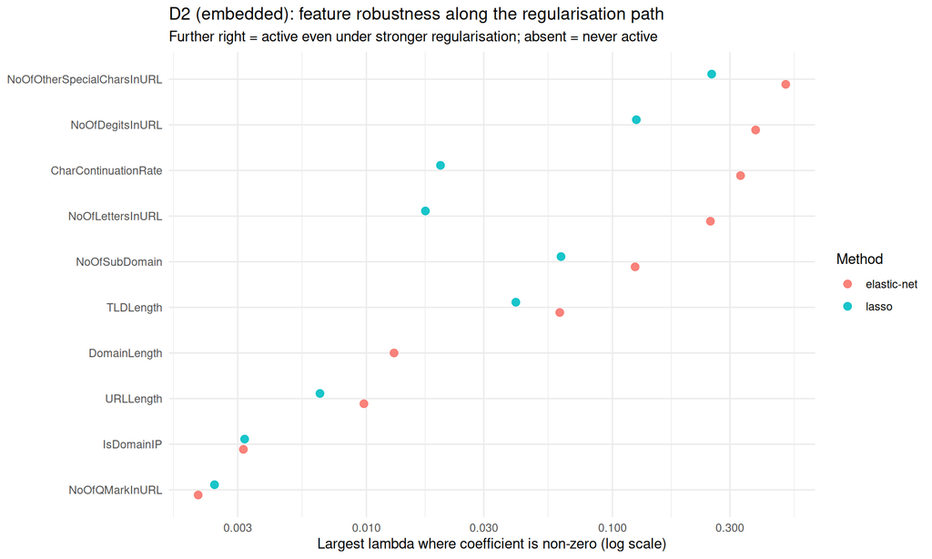

```r
embedded_lambda %>%
  filter(!is.na(active_lambda)) %>%
  mutate(predictor = reorder(predictor, active_lambda)) %>%
  ggplot(aes(active_lambda, predictor, colour = method)) +
  geom_point(size = 2.5, alpha = 0.9,
             position = position_dodge(width = 0.45)) +
  scale_x_log10() +
  labs(
    title = "D2 (embedded): feature robustness along the regularisation path",
    subtitle = "Further right = active even under stronger regularisation; absent = never active",
    x = "Largest lambda where coefficient is non-zero (log scale)",
    y = NULL,
    colour = "Method"
  ) +
  theme_minimal()
```

# 7. Secondary FullLite fallback benchmark

For each of the 10 outer CV folds we fit all three methods on the in-fold training rows and record only the count of selected predictors. This loop is a selected-predictor-count diagnostic, not a fold-level performance estimate.

Here we intentionally reuse the Scenario 2 train-split preprocessing for parity, and `glmnet` standardises columns internally again during fitting.

```r
perfold <- run_or_load("perfold", function() {
  k_step <- numeric(length(fold_idx))
  k_lasso <- numeric(length(fold_idx))
  k_en   <- numeric(length(fold_idx))
  step_terms_per_fold  <- vector("list", length(fold_idx))
  lasso_terms_per_fold <- vector("list", length(fold_idx))
  en_terms_per_fold    <- vector("list", length(fold_idx))

  t0 <- Sys.time()
  for (k in seq_along(fold_idx)) {
    trn <- train_std[fold_idx[[k]], c("label", predictors), drop = FALSE]

    sw   <- suppressWarnings(fit_stepwise(trn, predictors))
    sw_terms <- setdiff(names(coef(sw)), "(Intercept)")
    k_step[k] <- length(sw_terms)
    step_terms_per_fold[[k]] <- sw_terms

    cvl <- fit_glmnet(trn, alpha = 1)
    lasso_beta <- as.numeric(coef(cvl, s = "lambda.1se"))[-1]
    lasso_names <- colnames(model.matrix(label ~ . - 1, data = trn))
    lasso_terms <- lasso_names[lasso_beta != 0]
    k_lasso[k] <- length(lasso_terms)
    lasso_terms_per_fold[[k]] <- lasso_terms

    cve <- fit_glmnet(trn, alpha = 0.5)
    en_beta <- as.numeric(coef(cve, s = "lambda.1se"))[-1]
    en_terms <- lasso_names[en_beta != 0]
    k_en[k] <- length(en_terms)
    en_terms_per_fold[[k]] <- en_terms

    cat(sprintf("  fold %2d: step=%2d  lasso=%2d  EN=%2d\n",
                k, k_step[k], k_lasso[k], k_en[k]))
  }
  elapsed <- as.numeric(difftime(Sys.time(), t0, units = "secs"))

  list(k_step = k_step, k_lasso = k_lasso, k_en = k_en,
       step_terms = step_terms_per_fold,
       lasso_terms = lasso_terms_per_fold,
       en_terms = en_terms_per_fold,
       elapsed_secs = elapsed)
})
```

```
  [perfold] cache stale - refitting
  fold  1: step=17  lasso=23  EN=26
  fold  2: step=17  lasso=24  EN=27
  fold  3: step=17  lasso=23  EN=25
  fold  4: step=16  lasso=23  EN=25
  fold  5: step=18  lasso=23  EN=25
  fold  6: step=19  lasso=24  EN=25
  fold  7: step=20  lasso=24  EN=26
  fold  8: step=17  lasso=22  EN=26
  fold  9: step=18  lasso=24  EN=25
  fold 10: step=17  lasso=23  EN=24
```

```r
tibble(
  fold = seq_along(fold_idx),
  k_step  = perfold$k_step,
  k_lasso = perfold$k_lasso,
  k_en    = perfold$k_en
) %>%
  kable(caption = "Secondary FullLite fallback: selected-predictor count per CV fold (out of 34 candidates).")
```

Secondary FullLite fallback: selected-predictor count per CV fold (out of 34 candidates).

| fold | k_step | k_lasso | k_en |
| --- | --- | --- | --- |
| 1 | 17 | 23 | 26 |
| 2 | 17 | 24 | 27 |
| 3 | 17 | 23 | 25 |
| 4 | 16 | 23 | 25 |
| 5 | 18 | 23 | 25 |
| 6 | 19 | 24 | 25 |
| 7 | 20 | 24 | 26 |
| 8 | 17 | 22 | 26 |
| 9 | 18 | 24 | 25 |
| 10 | 17 | 23 | 24 |

## 7.1 FullLite lasso-vs-stepwise diagnostic

```r
wt <- wilcox.test(perfold$k_lasso, perfold$k_step,
                  paired = TRUE, alternative = "less", exact = FALSE)
wt_opposite <- wilcox.test(perfold$k_lasso, perfold$k_step,
                           paired = TRUE, alternative = "greater", exact = FALSE)
mean_step  <- mean(perfold$k_step)
mean_lasso <- mean(perfold$k_lasso)
mean_en    <- mean(perfold$k_en)
old_fulllite_expectation_supported <- mean_lasso < mean_step && wt$p.value < 0.05

tibble(
  metric = c("mean k (stepwise)", "mean k (lasso)", "mean k (elastic-net)",
              "Wilcoxon V", "p-value (diagnostic: lasso < step)",
             "descriptive p-value (opposite direction)",
              "old FullLite expectation"),
  value  = c(sprintf("%.1f", mean_step),
             sprintf("%.1f", mean_lasso),
             sprintf("%.1f", mean_en),
             sprintf("%.0f", unname(wt$statistic)),
             signif(wt$p.value, 3),
             signif(wt_opposite$p.value, 3),
             ifelse(old_fulllite_expectation_supported, "supported", "not supported"))
) %>% kable()
```

| metric | value |
| --- | --- |
| mean k (stepwise) | 17.6 |
| mean k (lasso) | 23.3 |
| mean k (elastic-net) | 25.4 |
| Wilcoxon V | 55 |
| p-value (diagnostic: lasso < step) | 0.998 |
| descriptive p-value (opposite direction) | 0.00272 |
| old FullLite expectation | not supported |

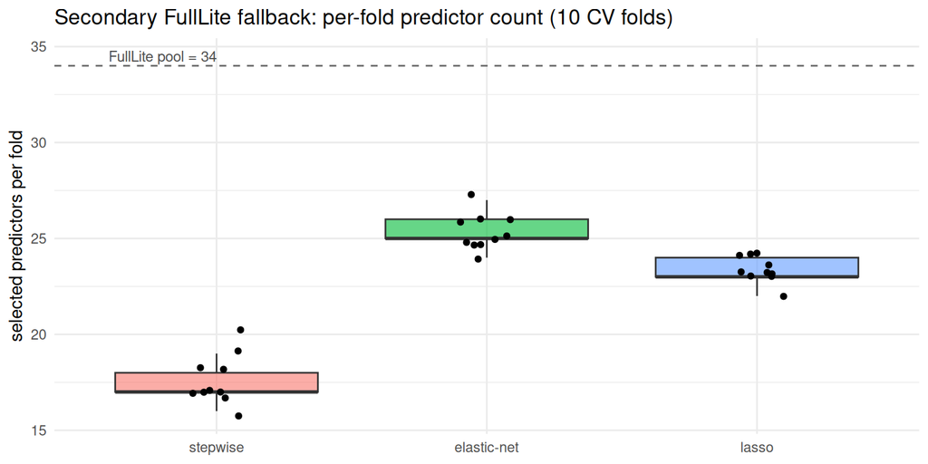

```r
perfold_long <- tibble(
  fold = rep(seq_along(fold_idx), 3),
  method = rep(c("stepwise", "lasso", "elastic-net"), each = length(fold_idx)),
  k = c(perfold$k_step, perfold$k_lasso, perfold$k_en)
) %>%
  mutate(method = factor(method, levels = c("stepwise", "elastic-net", "lasso")))

ggplot(perfold_long, aes(method, k, fill = method)) +
  geom_boxplot(alpha = 0.6, outlier.shape = NA) +
  geom_point(position = position_jitter(width = 0.1, seed = 1), size = 1.4) +
  geom_hline(yintercept = length(predictors), linetype = "dashed", colour = "grey40") +
  annotate("text", x = 0.6, y = length(predictors) + 0.5,
           label = sprintf("FullLite pool = %d", length(predictors)),
           hjust = 0, size = 3.2, colour = "grey30") +
  labs(x = NULL, y = "selected predictors per fold",
       title = "Secondary FullLite fallback: per-fold predictor count (10 CV folds)") +
  theme_minimal() + theme(legend.position = "none")
```

# 8. Conclusion

The primary Lexical URL-only result supports the project story. At least one requested feature-selection method, in this render Stepwise and Lasso, reduces the deployable URL filter and still meets the explicit AUC ≥ 0.95, Sensitivity ≥ 0.94 and Specificity ≥ 0.75 thresholds. Stepwise is the strongest deployable compromise because it combines compactness with the best held-out specificity; lasso is the embedded sparse confirmation, and elastic-net remains the required correlated-feature reference.